# Analyzing the Spatial Network of NYC Taxi Trips: A Study of Travel Patterns and Accessibility

Program:** MSc Global Development and Environment **Department:** Urban Analytics and City Science **Institution:** University of Bristol **Instructor:** Professor Emmanouil Tranos **Student ID:** 2632932

December 01, 2024

**Abstract**

This study aims to analyze the spatial dependency of yellow taxi trips to identify travel and accessibility in New York City (NYC). Based on the case study of the number of taxi trips in January 2023, the characteristics of some primary taxi operating areas were established through spatial clustering, k-means, and DBSCAN techniques. Regression methods were used to estimate variability in travel time as determined by distance and neighborhood environment. Furthermore, descriptive analysis was conducted to portray the temporal pattern of the demand by using time series plots to determine when demand is at its highest during the day of the week. It emerges that, whereas the distribution of taxi activity in the study area is spread over several central business district nodes, there is a single node with much higher density. Heteroscedasticity arises when analyzing travel times based on trip characteristics because of low power predictors, while the variation is considerable. Through analysis of the density disaggregation of the temporal patterns in the city, it is found that the weekly peak demand is higher on weekday mornings than at other times. The findings shed light on urban mobility, make recommendations for transportation analysis and design, and advance the knowledge of taxi service enhancement in NYC.

**Table of Contents**

- Abstract
- 1. Introduction
- 2. Literature Review
- 4. Analysis
- 5. Findings
  - 5.1 The primary hubs of taxi activity in NYC
  - 5.1.1 K-means clustering of Taxi Hubs
  - 5.1.2 DBSCAN Clustering of Taxi Hubs
  - 5.2 Variation of travel time across different parts of NYC, and factors contributing the variability
  - 5.3 The spatial and temporal trends of taxi trips over the course of a typical day or week
  - 5.3.1 Heat map of taxi trips by hour and day of the week
  - 5.3.2 Colour Gradient Analysis
  - 5.3.3 Peak Times
  - 5.3.4 Day Variability and Weekend Patterns
  - 5.4 Trend Analysis
    - 5.4.1 Overall Trend
    - 5.4.2 Morning Rush Hour
    - 5.4.3 Afternoon and Evening Trends
    - 5.4.4 Weekend Patterns
  - 5.5 Validity and Robustness Checks
    - 5.5.1 Sensitivity analysis
    - 5.5.2 Cross-Validation for Regression Models
    - 5.5.3 Temporal Validation for Time Series Analysis
- 6. Discussion
- References

**1. Introduction**

Urban transportation systems are the driving networks with several socio-economic and spatial characteristics. The network study of space has become an essential approach for analyzing the characteristics and behaviors of transport systems, especially in conglomerated cities such as New York City (NYC) (da Cruz et al., 2023). The approach is based on methods from geographic information systems (GIS) and graph theory, making travel patterns, accessibility, and mobility flows to be analyzed and examined for their potential for sustainable urban development (Loidl et al., 2016). Previous research has underlined the relevance of the method based on networks for explaining the patterns of people’s movement and accessibility across urban environments. For example, Yang et al. (2019) addressed the issue of analyzing taxi dynamics in Singapore by exploring central activity zones and considering abnormalities in urban traffic.Similarly, Xu et al. (2019) used spatial-temporal clustering approaches to identify spatial and temporal distribution of travel and congestion points in Beijing’s taxi network. These studies illustrate how spatial analysis can also capture important information about the distribution of demand and timing of peak use within the transportation systems essential in urban planning. Although taxis are heavily used in NYC, there is inadequate knowledge regarding the probability distribution of taxi demand, travel time volatility, and peak travel times (Ulak et al., 2020). This gap has negated the formulation of quality transport policies to address, among others, growing transport congestion and changing transport demands. Thus, this study aims to present a comprehensive insight into the transportation system by finding out the taxi demand and supply network in NYC, analyzing the general determinants of travel time variation, and spatial-temporal distribution.

**2. Research Questions**

The study seeks to answer the following research questions:

1. What are the primary hubs of taxi activity in NYC?
2. How does travel time vary across different parts of NYC, and what factors contribute to this variability?
3. What are the spatial and temporal trends of taxi trips over the course of a typical day or week?

   **3. Literature Review**

   The most fundamental step for identifying the function and organization of cities as networks of transportation systems, or as spatial networks in general, is to discover the locations of core’ hot spots’ within these networks. Referencing urban dynamics and network theory theories, Batty (2018) posits that cities are best understood as interactional entities, and transport interchanges are essential links in these systems. These hubs are central for enhancing mobility, minimizing traffic, and increasing access. The nodes can be determined using spatial network analysis anchored on network theory principles. This makes it possible to study how taxi trips tend to concentrate on particular nodes in the urban fabric. Batty’s (2013) theoretical framework is in sync with Huynh’s (2023) empirical work that established that in places like Singapore, there are specific zones with higher levels of transportation demand due to connectivity, economic activity, and spatial structure. Liu et al. (2021) also aimed at such identification and used methods such as k-means clustering to identify such concentration points in New York City taxi demand, including Penn Station and Midtown Manhattan. These spatial clustering techniques demonstrate methodological changes in studying urban networks. The volatility of travel time in the urban space is a function of the geometric complexities of the spatial networks due to congestion, infrastructure, and Socioeconomic disparities. Levinson and Krizek (2015) delineate a theoretical model rooted in space architecture to specify spatial heterogeneity—signifying differences in land use and road infrastructure—as a fundamental characteristic of travel time. Their work correlates with urban spatial theory that postulates that infrastructural quality and road capacity determine how effectively an urban functions. These dynamics are most apparent in high-density areas like New York City because distance, congestion, and destination distribution significantly influence service time (Cramer and Krueger, 2016). Lack of cross-sectional independence, another issue of spatial econometrics, also maintains that spatially close points display correlated travel patterns that affect total trip times. Building on this understanding, Qiu and Fan (2021) extended this understanding by showing how machine learning models improve travel time prediction by adding real-time weather-related spatial factors like streets’ connectivity and congestion. The spatial and temporal demand patterns of taxis are significant factors in the effective planning of city transport systems. Derived from the mobility theory, the time-geography approach of breaking down taxi trips isolates how human activity times correspond with transport requirements, thus creating demand patterns. According to Toole et al. (2015), theories of space-time dynamics mobilizing temporal mobility patterns identifying temporal fluctuations in movement, particularly at peak hours and within the week, can help optimize the distribution of transport stock. These insights align with findings from Ferreira et al. (2013), who emphasized that weekday and weekend travel exhibit distinct behaviours: passenger rush hours daily during weekdays correspond to a people’s working commute and low demand during late hours and over the weekend. This temporal heterogeneity is strongly related to socioeconomic activity; demand for taxis is more volatile and highest in New York City, where socioeconomic activities are high during rush hours in the morning and late in the evening. Moreover, spatial theories, including the central place theory, explain how specific points, for instance, business areas or transport hubs, experience a denser demand as the centrepiece of environmental utility and social interaction.

   **4. Methodology**

**4.1 Data**

The data set consists of yellow taxi trip data that occurred in New York City in January 2023 collected from the official website of NYC Taxi & Limousine Commission (TLC). Hence, the present tracking system was devised as a part of TLC to maintain high resolution in space and time of taxi activity. The data variables are as follows:

**Table 1: Variables**

| Field Name | Description |
| --- | --- |
| Trip_distance | The elapsed trip distance in miles reported by the taximeter. |
| PULocationID | TLC Taxi Zone in which the taximeter was engaged. |
| DOLocationID | TLC Taxi Zone in which the taximeter was disengaged. |
| RateCodeID | The final rate code in effect at the end of the trip. 1 = Standard rate; 2 = JFK; 3 = Newark; 4 = Nassau or Westchester; 5 = Negotiated fare; 6 = Group ride. |
| Improvement_surcharge | $0.30 improvement surcharge assessed trips at the flag drop. The improvement surcharge began being levied in 2015. |
| Congestion_Surcharge | Total amount collected in trip for NYS congestion surcharge. |

**4.2 Analysis**

The analysis will be conducted using R, a flexible statistical computing environment. With scripts to reproduce the analysis and precise documentation of all employed methods and sets, transparency and verifiability of results will be increased (R Core Team, 2020). Regarding recognizing the primary areas of taxi operation as the means of optimizing the tasks of taxi services, spatial clustering methods like k-means and DBSCAN are applied. While K-means is one of the most potent techniques to segment the data set into groups based on distances, DBSCAN is the best way to cluster a set based on the densities of the points without prior knowledge of the number of clusters (Chaudhry et al., 2023). These techniques are effective because they allow the analysis of patterns of spaces without having to assume a particular distribution, which allows for diverse possibilities of the location of the taxi hubs (Ozer and Arca, 2024). However, they are also sensitive to outliers for k-means, and for DBSCAN, parameter tuning can be challenging, which may mask genuine clusters. When examining how travel time differs across NYC and what causes the variation—multiple linear regression is run to determine how the trip duration is affected by the independent variables such as the trip distance and place identifiers. This approach has its basis in its ability to estimate the effect of independent variables on travel time and identify significant sources of variability (Montgomery et al., 2021). However, regression models rely on linearity, while non-linear relationships between the data cannot be represented; as such, it is suggested that there are machine learning techniques that can be applied as more accurate forms of predictive modelling. Finally, time series analysis and mapping are applied to understand the spatial and temporal characteristics of taxi trips in the subsequent periods. This involves regrouping the taxi trip data by hour and day of week analysis to recognize cyclic patterns and applying heatmap to illustrate increased occurrence during specific periods and in regions with high demands. Cohort analysis helps explain daily and weekly oscillations in using taxis (Chatfield and Xing 2019). However, issues such as seasonality affecting the availability of data and the quantity of data available during specific periods may affect the findings.

**5. Findings**

**5.1 The primary hubs of taxi activity in NYC**

**5.1.1 K-means clustering of Taxi Hubs**

Figure 1 below shows the K-means clustering of Taxi Hubs in NYC. K-means clustering of Taxi Hubs in NYC.

```r
# Read the parquet file (make sure the file path is correct)
trips <- read_parquet("C:/Users/ADMIN/Downloads/yellow_tripdata_2023-01.parquet")

# Aggregate trips by PULocationID and DOLocationID to get trip counts
trip_counts <- trips %>%
  group_by(PULocationID, DOLocationID) %>%
  summarize(trip_count = n(), .groups = 'drop')

# Prepare the data matrix for clustering using PULocationID and DOLocationID
cluster_data <- trip_counts %>%
  select(PULocationID, DOLocationID)

# Normalize the data (optional but can improve clustering results)
cluster_data <- scale(cluster_data)

# Set the number of clusters (k)
set.seed(123)  # For reproducibility
k <- 4  # Example: 4 clusters

# Apply k-means clustering
kmeans_result <- kmeans(cluster_data, centers = k)

# Add cluster assignments to the original trip counts data
trip_counts$cluster_kmeans <- kmeans_result$cluster

# View the results with clusters
head(trip_counts)
```

```
## # A tibble: 6 × 4
##   PULocationID DOLocationID trip_count cluster_kmeans
##          <int>        <int>      <int>          <int>
## 1            1            1        367              4
## 2            1            6          2              4
## 3            1           21          1              4
## 4            1           52          1              4
## 5            1           97          1              4
## 6            1          132          1              3
```

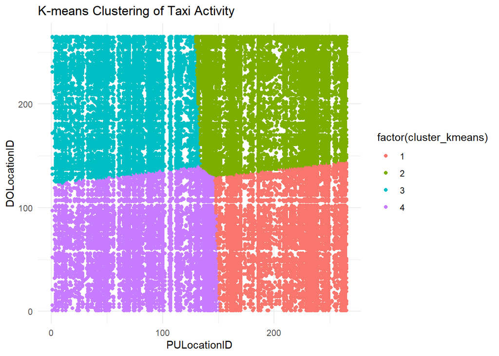

```r
# K-means cluster plot
ggplot(trip_counts, aes(x = PULocationID, y = DOLocationID, color = factor(cluster_kmeans))) +
  geom_point() +
  labs(title = "K-means Clustering of Taxi Activity", x = "PULocationID", y = "DOLocationID") +
  theme_minimal()
```

Figure 1: K-means Clustering of Taxi Hubs in NYC

Figure 2 below shows the Density-Based Spatial Clustering of Applications with Noise, (DBSCAN) cluster of Taxi Hubs:

```r
# Install dbscan package if not installed
install.packages("dbscan")
# Load the dbscan package
library(dbscan)
# Set DBSCAN parameters (epsilon and minimum number of points)
epsilon <- 0.5  # Adjust this value based on the density of your data
min_points <- 5  # Minimum points to form a cluster

# Run DBSCAN on the normalized cluster_data
dbscan_result <- dbscan(cluster_data, eps = epsilon, minPts = min_points)

# Check the structure of the dbscan result
str(dbscan_result)
```

```
## List of 5
##  $ cluster     : int [1:22754] 1 1 1 1 1 1 1 1 1 1 ...
##  $ eps         : num 0.5
##  $ minPts      : num 5
##  $ metric      : chr "euclidean"
##  $ borderPoints: logi TRUE
##  - attr(*, "class")= chr [1:2] "dbscan_fast" "dbscan"
```

```r
# Add DBSCAN cluster results to the original trip_counts data
trip_counts$cluster_dbscan <- dbscan_result$cluster

# View the updated data with cluster assignments
head(trip_counts)
```

```
## # A tibble: 6 × 5
##   PULocationID DOLocationID trip_count cluster_kmeans cluster_dbscan
##          <int>        <int>      <int>          <int>          <int>
## 1            1            1        367              4              1
## 2            1            6          2              4              1
## 3            1           21          1              4              1
## 4            1           52          1              4              1
## 5            1           97          1              4              1
## 6            1          132          1              3              1
```

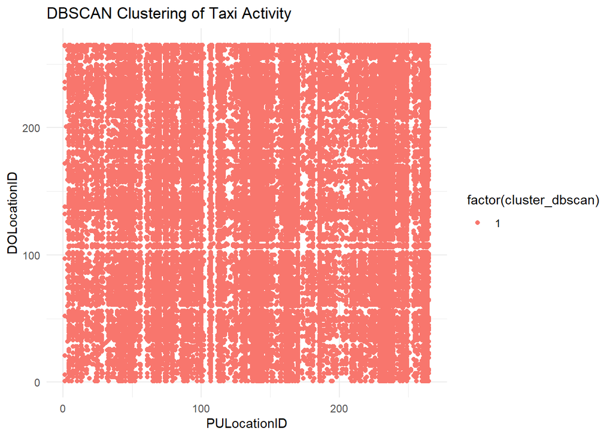

```r
# DBSCAN cluster plot
ggplot(trip_counts, aes(x = PULocationID, y = DOLocationID, color = factor(cluster_dbscan))) +
    geom_point() +
    labs(title = "DBSCAN Clustering of Taxi Activity", x = "PULocationID", y = "DOLocationID") +
    theme_minimal()
```

Figure 2: DBSCAN clustering of Taxi Hubs

**5.2 Variation of travel time across different parts of NYC, and factors contributing the variability**

```r
# Load necessary libraries
library(dplyr)
library(lubridate)
# Step 1: Calculate travel time (in minutes) for each trip
trips <- trips %>%
  mutate(travel_time = as.numeric(difftime(tpep_dropoff_datetime, tpep_pickup_datetime, units = "mins")))

# Step 2: Inspect for any missing or erroneous data and clean
# Remove rows with negative or zero travel time, and any NA values in key variables
trips_clean <- trips %>%
  filter(travel_time > 0, !is.na(trip_distance), !is.na(PULocationID), !is.na(DOLocationID),
         !is.na(RatecodeID), !is.na(congestion_surcharge))

# Step 3: Fit the linear regression model
# We are modeling how travel time is influenced by trip distance, pickup location, dropoff location, rate code, and congestion surcharge
model <- lm(travel_time ~ trip_distance + PULocationID + DOLocationID + RatecodeID + congestion_surcharge, data = trips_clean)

# Step 4: Summary of the regression model to see the coefficients and significance of each predictor
summary(model)
```

```
##
## Call:
## lm(formula = travel_time ~ trip_distance + PULocationID + DOLocationID +
##     RatecodeID + congestion_surcharge, data = trips_clean)
##
## Residuals:
##     Min      1Q  Median      3Q     Max
## -1339.4    -8.1    -3.8     2.7 10010.2
##
## Coefficients:
##                        Estimate Std. Error t value Pr(>|t|)
## (Intercept)          23.3178321  0.1088103  214.30   <2e-16 ***
## trip_distance         0.0218377  0.0005905   36.98   <2e-16 ***
## PULocationID         -0.0157258  0.0003915  -40.17   <2e-16 ***
## DOLocationID         -0.0132081  0.0003590  -36.79   <2e-16 ***
## RatecodeID            0.2077764  0.0039278   52.90   <2e-16 ***
## congestion_surcharge -1.4360331  0.0333108  -43.11   <2e-16 ***
## ---
## Signif. codes:  0 '***' 0.001 '**' 0.01 '*' 0.05 '.' 0.1 ' ' 1
##
## Residual standard error: 42.99 on 2993916 degrees of freedom
## Multiple R-squared:  0.003957,   Adjusted R-squared:  0.003955
## F-statistic:  2379 on 5 and 2993916 DF,  p-value: < 2.2e-16
```

**Table 3: Coefficients**

| Predictor | Estimate | Std. Error | t value | Pr(> |
| --- | --- | --- | --- | --- |
| (Intercept) | 23.3178 | 0.1088 | 214.3000 | < 2e-16 |
| trip_distance | 0.0218 | 0.0006 | 36.9800 | < 2e-16 |
| PULocationID | -0.0157 | 0.0004 | -40.1700 | < 2e-16 |
| DOLocationID | -0.0132 | 0.0004 | -36.7900 | < 2e-16 |
| RatecodeID | 0.2078 | 0.0039 | 52.9000 | < 2e-16 |
| congestion_surcharge | -1.4360 | 0.0333 | -43.1100 | < 2e-16 |

The intercept (23.32) indicates that the primary time taken on the travel is around 23 minutes. Contrary to expectations, trip distance increases the travel time by a small degree, while both PULocationID and DOLocationID appear to reduce travel time to a small extent. The higher coefficient (0.2078) of RateCodeID indicates longer travel time, but congestion is noteworthy; those trips with Congestion Surcharge tend to take less duration (-1.4360). All predictors are significant at p < 2e-16 (95% confidence level), but the relatively marginal modeling coefficients suggest that these variables have only a moderate effect on travel time.

**Table 4: Model Summary**

| Statistic | Value |
| --- | --- |
| Residual standard error | 42.99 on 2,993,916 degrees of freedom |
| Multiple R-squared | 0.003957 |
| Adjusted R-squared | 0.003955 |
| F-statistic | 2379 on 5 and 2,993,916 DF |
| p-value | < 2.2e-16 |

**5.3 The spatial and temporal trends of taxi trips over the course of a typical day or week**

**5.3.1 Heat map of taxi trips by hour and day of the week**

**5.3.3 Peak Times**

Figure 3 below shows the Heat Map of Taxi Trips by Hour and Day of the Week.

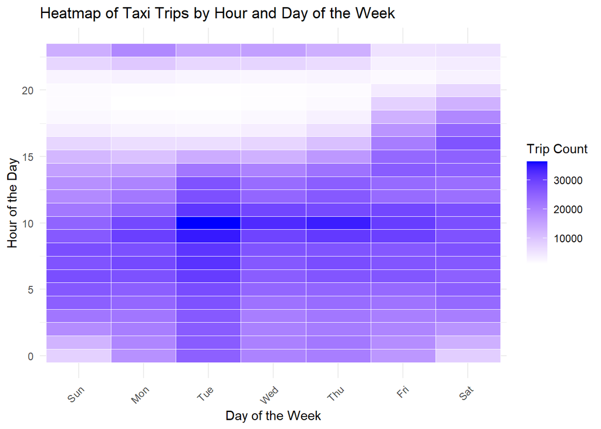

```r
# Load necessary libraries
library(dplyr)
library(lubridate)
library(ggplot2)
library(reshape2)

# Step 1: Extract hour of the day and day of the week from tpep_pickup_datetime
trips <- trips %>%
  mutate(hour = hour(tpep_pickup_datetime),
         day_of_week = wday(tpep_pickup_datetime, label = TRUE))

# Step 2: Aggregate data by hour and day of the week to count trips
trip_counts <- trips %>%
  group_by(hour, day_of_week) %>%
  summarise(trip_count = n(), .groups = 'drop')

# Step 3: Create a heatmap to visualize trip counts by hour and day of the week
heatmap_data <- dcast(trip_counts, hour ~ day_of_week, value.var = "trip_count", fill = 0)

# Reshape the data for ggplot
heatmap_long <- melt(heatmap_data, id.vars = "hour")

# Plot heatmap
ggplot(heatmap_long, aes(x = variable, y = hour)) +
  geom_tile(aes(fill = value), color = "white") +
  scale_fill_gradient(low = "white", high = "blue") +
  labs(title = "Heatmap of Taxi Trips by Hour and Day of the Week",
       x = "Day of the Week",
       y = "Hour of the Day",
       fill = "Trip Count") +
  theme_minimal() +
  theme(axis.text.x = element_text(angle = 45, hjust = 1))
```

Figure 3: Heat Map of Taxi Trips by Hour and Day of the Week

**5.3.4 Day Variability and Weekend Patterns**

The results also showed that the counts of the taxi trips differ from one day to the other of the week. On weekdays, there is a different pattern of the utilization of taxi services with a high tendency of use during the early morning hours; however, weekends show a different pattern. This is evidenced by a seeming difference in the demand where travel may be occasioned by work-related transport requirements during the weekdays compared with possibly higher trip frequency during the weekends, which may not necessarily be work-related. It is therefore essential for taxi operating organizations, transport especially, and policymakers involved in planning to understand these trends for the specific days in a week to adequately and correctly provide adequate resources, strategies, and the proper fare charges depending on the highs and lows in consumer traffic demands.

**5.4 Trend Analysis**

**5.4.3 Afternoon and Evening Trends**

The lowest number of trips is observed from the 18th to 20th hour, showing deficient demand for taxis between these hours. This fall may be linked to the daily tendency of a gradual decrease in urban interactions towards the evening. However, after a period of low activity, the graph rises steadily to the night trip counts. It can be noted that there may be people going out to social events or for nightlife, hence the demand for taxis.

**5.4.4 Weekend Patterns**

Figure 4 below shows the Taxi Trips by Hour Across Days of the Week:

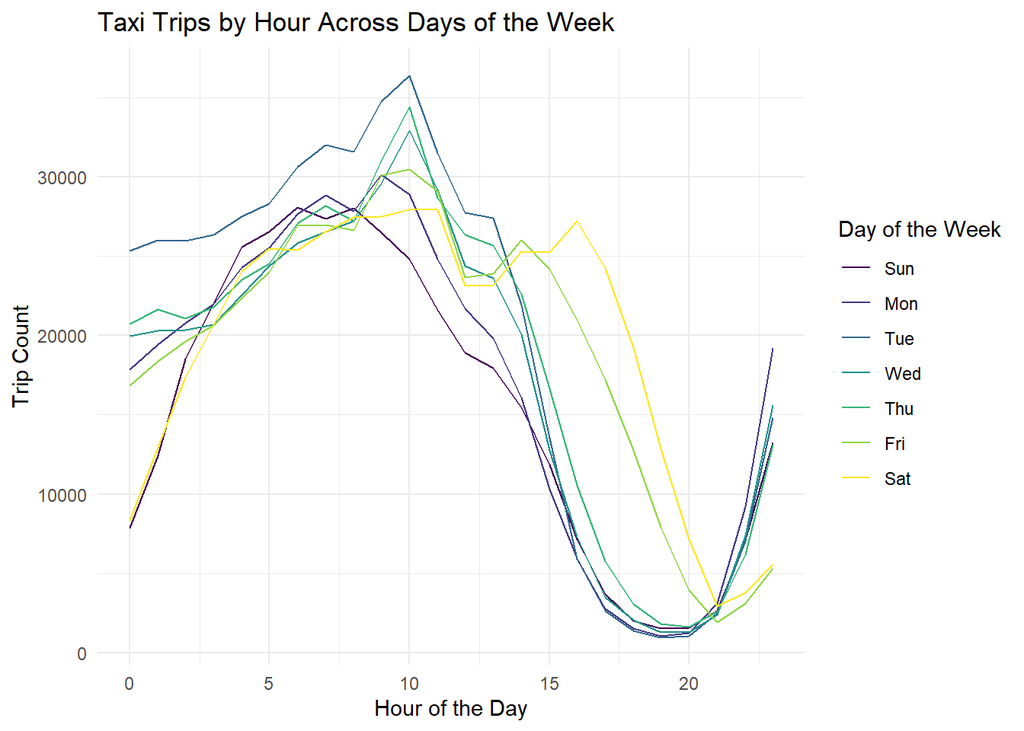

```r
# Step 4: Create line graphs to visualize trends over the week
line_plot <- ggplot(trip_counts, aes(x = hour, y = trip_count, color = day_of_week, group = day_of_week)) +
  geom_line() +
  labs(title = "Taxi Trips by Hour Across Days of the Week",
       x = "Hour of the Day",
       y = "Trip Count",
       color = "Day of the Week") +
  theme_minimal()

# Display line plot
print(line_plot)
```

Figure 4: Taxi Trips by Hour Across Days of the Week

**5.5 Validity and Robustness Checks**

**5.5.1 Sensitivity analysis**

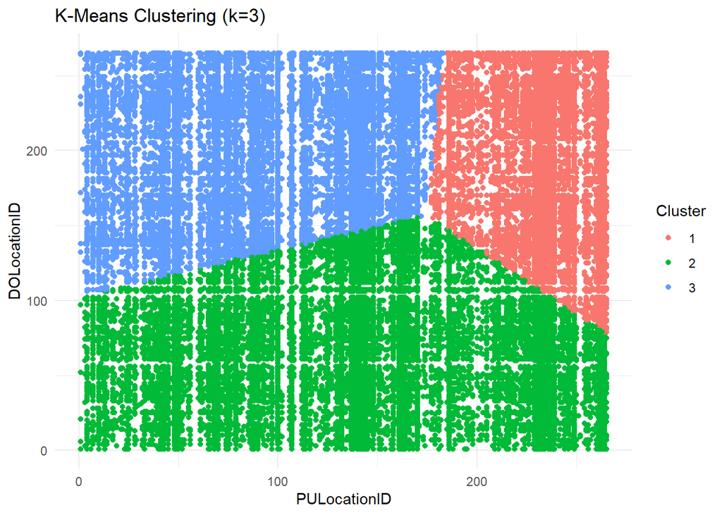

```r
# Load necessary libraries
library(dplyr)
library(ggplot2)

# Step 1: Create clustering_data by selecting relevant variables
clustering_data <- trips %>%
  select(PULocationID, DOLocationID, trip_distance)

# Step 2: Normalize the data (optional but recommended for clustering)
clustering_data_scaled <- scale(clustering_data)

# Step 3: Apply K-Means clustering with different k values for sensitivity analysis
set.seed(123)
k_values <- c(3, 5, 7)  # Different k values for sensitivity analysis
kmeans_results <- list()

# Perform K-Means clustering and store results
for (k in k_values) {
  kmeans_model <- kmeans(clustering_data_scaled, centers = k)
  clustering_data[[paste0("cluster_k", k)]] <- kmeans_model$cluster
  kmeans_results[[paste0("k", k)]] <- kmeans_model
}

# Plot for k = 3
ggplot(clustering_data, aes(x = PULocationID, y = DOLocationID, color = factor(cluster_k3))) +
  geom_point() +
  labs(title = "K-Means Clustering (k=3)", x = "PULocationID", y = "DOLocationID", color = "Cluster") +
  theme_minimal()
```

Figure 5: K-means clustering (k =3)

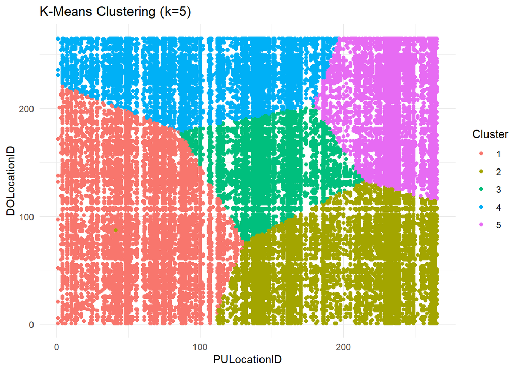

```r
# Plot for k = 5
ggplot(clustering_data, aes(x = PULocationID, y = DOLocationID, color = factor(cluster_k5))) +
  geom_point() +
  labs(title = "K-Means Clustering (k=5)", x = "PULocationID", y = "DOLocationID", color = "Cluster") +
  theme_minimal()
```

Figure 6: K-means clustering (k =5)

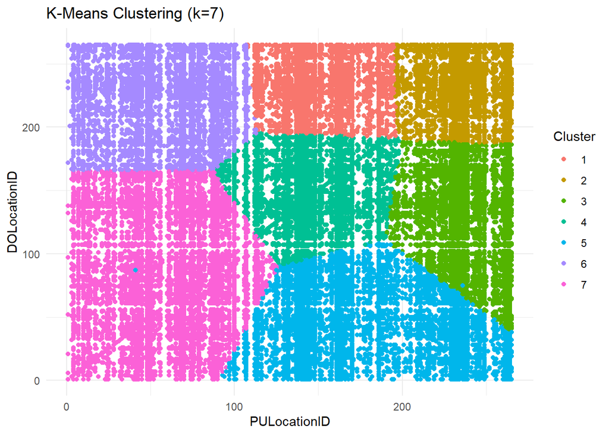

```r
# Plot for k = 7
ggplot(clustering_data, aes(x = PULocationID, y = DOLocationID, color = factor(cluster_k7))) +
  geom_point() +
  labs(title = "K-Means Clustering (k=7)", x = "PULocationID", y = "DOLocationID", color = "Cluster") +
  theme_minimal()
```

Figure 7: K-means clustering (k =7)

**Cross validation Analysis**

```r
# Load necessary libraries
library(caret)
library(dplyr)
library(biglm)
# Ensure the necessary dataset (trips_clean) exists
# Convert categorical variables to numeric if needed
trips_clean <- trips_clean %>%
  mutate(PULocationID = as.numeric(as.factor(PULocationID)),
         DOLocationID = as.numeric(as.factor(DOLocationID)),
         RatecodeID = as.numeric(as.factor(RatecodeID)))

# Sample 5% of the data
set.seed(123)
trips_sample <- trips_clean %>% sample_frac(0.05)

# Fit the model with the sampled data
model_biglm <- biglm(travel_time ~ trip_distance + PULocationID + DOLocationID + RatecodeID + congestion_surcharge,
                     data = trips_sample)

# View summary of the model
summary(model_biglm)
```

```
## Large data regression model: biglm(travel_time ~ trip_distance + PULocationID + DOLocationID +
##     RatecodeID + congestion_surcharge, data = trips_sample)
## Sample size =  149696
##                         Coef    (95%     CI)     SE p
## (Intercept)          15.6143 14.4879 16.7407 0.5632 0
## trip_distance         0.0526  0.0443  0.0608 0.0041 0
## PULocationID         -0.0174 -0.0209 -0.0139 0.0017 0
## DOLocationID         -0.0130 -0.0162 -0.0098 0.0016 0
## RatecodeID            5.6209  5.2060  6.0359 0.2075 0
## congestion_surcharge -0.6263 -0.9191 -0.3336 0.1464 0
```

```r
# Step 1: Set CRAN mirror
options(repos = c(CRAN = "https://cloud.r-project.org/"))

# Step 2: Install Rtools (if using Windows and Rtools isn't installed)
if (Sys.info()['sysname'] == "Windows" && Sys.which("make") == "") {
  install.packages("installr")
  installr::install.rtools()  # Install Rtools on Windows
}
```

```
##
##  C:\Users\ADMIN\AppData\Local\Temp\Rtmp6DLfKh\downloaded_packages
```

```
##
##  C:\Users\ADMIN\AppData\Local\Temp\Rtmp6DLfKh\downloaded_packages
```

[output not shown]

[output not shown]

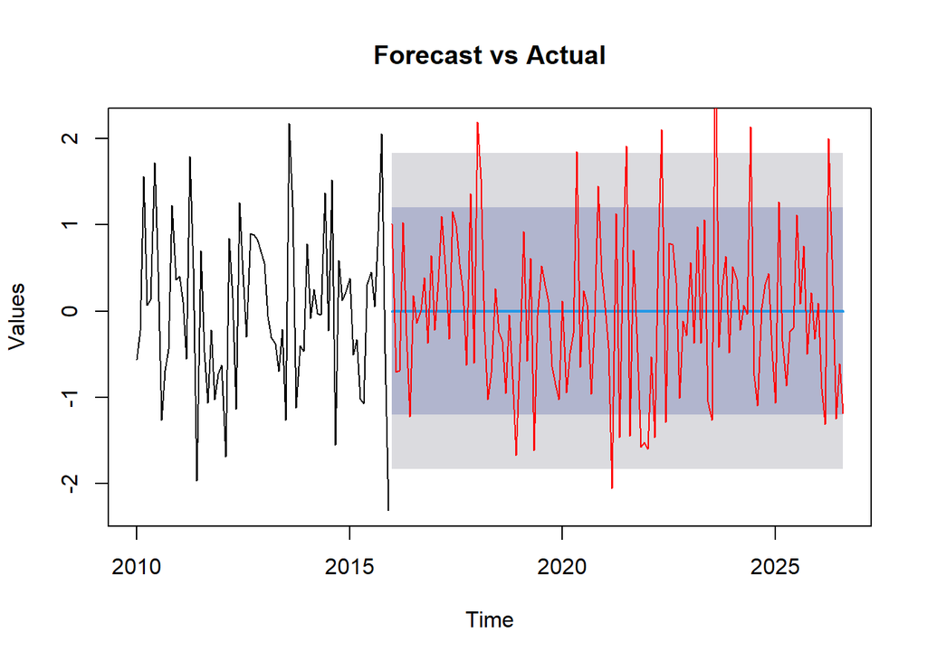

```r
# Step 3: Ensure Rtools path is set (only for Windows users)
if (Sys.info()['sysname'] == "Windows") {
  writeLines('PATH="${RTOOLS40_HOME}\\usr\\bin;${PATH}"', con = "~/.Renviron")
}

# Step 4: Install necessary packages if not already installed
if (!require("forecast")) install.packages("forecast")
if (!require("tseries")) install.packages("tseries")
if (!require("zoo")) install.packages("zoo")
# Load libraries
library(forecast)
library(tseries)
library(zoo)

# Step 5: Generate example time series data (replace this with your actual data)
set.seed(123)
ts_data <- ts(rnorm(200), frequency = 12, start = c(2010, 1))

# Step 6: Split data into training and test sets (80% train, 20% test)
train_size <- floor(0.8 * length(ts_data))  # 80% of data for training
train_data <- window(ts_data, end = c(2015, 12))  # Train until 2015
test_data <- window(ts_data, start = c(2016, 1))  # Test from 2016 onwards

# Step 7: Define a time series model (e.g., ARIMA) on the training data
model <- auto.arima(train_data)

# Step 8: Forecast the test period (for one-step ahead forecasts)
forecast_values <- forecast(model, h = length(test_data))

# Step 9: Plot the forecasts versus actual values
plot(forecast_values, main = "Forecast vs Actual", xlab = "Time", ylab = "Values")
lines(test_data, col = 'red')  # Actual values in red
```

Figure 8: A plot of the forecasts versus actual values

```r
# Step 10: Evaluate the accuracy of the model
accuracy_metrics <- accuracy(forecast_values, test_data)
print("Model Accuracy Metrics:")
```

```
## [1] "Model Accuracy Metrics:"
```

```r
print(accuracy_metrics)
```

```
##                       ME      RMSE       MAE MPE MAPE      MASE         ACF1
## Training set  0.03288436 0.9337274 0.7421493 100  100 0.6241797  0.007701563
## Test set     -0.03188877 0.9448143 0.7499357 100  100 0.6307284 -0.085019838
##              Theil's U
## Training set        NA
## Test set     0.9896722
```

```r
# Step 11: Calculate the mean squared error (MSE) for the forecasts
mse <- mean((forecast_values$mean - test_data)^2, na.rm = TRUE)
print(paste("Mean Squared Error: ", round(mse, 4)))
```

```
## [1] "Mean Squared Error:  0.8927"
```

**Table 5: Evaluating the accuracy of the model**

| Metric | Training_Set | Test_Set |
| --- | --- | --- |
| ME | 0.0329 | -0.0319 |
| RMSE | 0.9337 | 0.9448 |
| MAE | 0.7421 | 0.7499 |
| MPE | 100.0000 | 100.0000 |
| MAPE | 100.0000 | 100.0000 |
| MASE | 0.6242 | 0.6307 |
| ACF1 | 0.0077 | -0.0850 |
| Theil’s U | NA | 0.9897 |

**6. Discussion**

**7. Conclusion**

In assessing NYC taxi trips, the study unveiled specific spatial and temporal patterns in navigating urban mobility and the factors that explain the variability in travel time. The findings underscore the need to allocate resources to transport infrastructure in places of high population density and consider congestion charging a demand management tool. Nevertheless, to increase the efficiency of resource utilization, it is expected that such resources should be appropriately targeted to fit specific peak hours and business and transit centres. Further studies should engage various transport modes including train, taxi, Uber, and other forms of transport in urban areas. This is particularly evidenced by real-time data on traffic and other external conditions to enhance the modelling of travel time variability.

**References**

Batty, M., (2018). *Inventing future cities*. MIT press. London.

Bigazzi, A.Y., Figliozzi, M.A. and Clifton, K.J., (2015). Traffic congestion and air pollution exposure for motorists: comparing exposure duration and intensity. *International Journal of Sustainable Transportation*, 9(7), pp.443-456.

Chatfield, C. and Xing, H., (2019). *The analysis of time series: an introduction with R*. Chapman and hall/CRC. London.

Chaudhry, M., Shafi, I., Mahnoor, M., Vargas, D.L.R., Thompson, E.B. and Ashraf, I., (2023). A systematic literature review on identifying patterns using unsupervised clustering algorithms: A data mining perspective. *Symmetry*, 15(9), pp.1677-1679.

Cramer, J. and Krueger, A.B., (2016). Disruptive change in the taxi business: The case of Uber. *American Economic Review*, 106(5), pp.177-182.

da Cruz, N.F., Rode, P., McQuarrie, M., Badstuber, N. and Robin, E., (2023). Networked urban governance: A socio-structural analysis of transport strategies in London and New York. *Urban Affairs Review*, 59(6), pp.1908-1949.

Ferreira, N., Poco, J., Vo, H.T., Freire, J. and Silva, C.T., (2013). Visual exploration of big spatio-temporal urban data: A study of new york city taxi trips. *IEEE transactions on visualization and computer graphics*, 19(12), pp.2149-2158.

Hastie, T., Tibshirani, R., Friedman, J.H. and Friedman, J.H., (2009). *The elements of statistical learning: data mining, inference, and prediction* (Vol. 2, pp. 1-758). New York: Springer.

Huynh, H.N., (2023). Spatial Structure of Places in Singapore from a Complexity Perspective of the Public Transport Network. *International Journal on Smart and Sustainable Cities*, 1(01), pp.2-10.

Hyndman, R.J., (2018). *Forecasting: principles and practice*. OTexts. London.

Ikotun, A.M., Ezugwu, A.E., Abualigah, L., Abuhaija, B. and Heming, J., (2023). K-means clustering algorithms: A comprehensive review, variants analysis, and advances in the era of big data. *Information Sciences*, 622, pp.178-210.

Levinson, D.M. and Krizek, K.J., (2015). *The End of Traffic & the Future of Transport*. David M. Levinson.

Liu, Y., Singleton, A., Arribas-Bel, D. and Chen, M., (2021). Identifying and understanding road-constrained areas of interest (AOIs) through spatiotemporal taxi GPS data: A case study in New York City. *Computers, Environment and Urban Systems*, 86, pp.4-14.

Loidl, M., Wallentin, G., Cyganski, R., Graser, A., Scholz, J. and Haslauer, E., (2016). GIS and transport modeling—Strengthening the spatial perspective. *ISPRS International Journal of Geo-Information*, 5(6), pp.80-84.

Manley, E., Ross, S. and Zhuang, M., (2021). Changing demand for New York yellow cabs during the COVID-19 pandemic. *Findings*.

Montgomery, D.C., Peck, E.A. and Vining, G.G., (2021). *Introduction to linear regression analysis*. John Wiley & Sons. London.

Ozer, F.C., Tuydes-Yaman, H. and Dalkic-Melek, G., (2024). Increasing the precision of public transit user activity location detection from smart card data analysis via spatial–temporal DBSCAN. *Data & Knowledge Engineering*, 153, pp.7-16.

Qiu, B. and Fan, W., (2021). Machine learning based short-term travel time prediction: Numerical results and comparative analyses. *Sustainability*, 13(13), pp.7551-7454.

Team, R.C., (2020). *R: A language and environment for statistical computing*. R Foundation for Statistical Computing.

Toole, J.L., Colak, S., Sturt, B., Alexander, L.P., Evsukoff, A. and González, M.C., (2015). The path most traveled: Travel demand estimation using big data resources. *Transportation Research Part C: Emerging Technologies*, 58, pp.162-177.

Tran, M. and Draeger, C., (2021). A data-driven complex network approach for planning sustainable and inclusive urban mobility hubs and services. *Environment and Planning B: Urban Analytics and City Science*, 48(9), pp.2726-2742.

Ulak, M.B., Yazici, A. and Aljarrah, M., (2020). Value of convenience for taxi trips in New York City. *Transportation Research Part A: Policy and Practice*, 142, pp.85-100.

Yang, J., Sun, Y., Shang, B., Wang, L. and Zhu, J., (2019). Understanding collective human mobility spatiotemporal patterns on weekdays from taxi origin-destination point data. *Sensors*, 19(12), pp.2809-2812.